# Midterm Assignemnt, ME314 2019

#### Summer School 2019 midsession examination

# ME314 Introduction to Data Science and Machine Learning

## Suitable for all candidates

### Instructions to candidates

- Complete the assignment by adding your answers directly to the RMarkdown document, knitting the document, and submitting the HTML file to Moodle.
- Time allowed: due 19:00 on Wednesday, 7th August 2019.
- Submit the assignment via [Moodle](https://shortcourses.lse.ac.uk/course/view.php?id=158).

## Question 1:

This question should be answered using the `Carseats` data set, which is part of the **ISLR** package. This data contains simulated data set containing sales of child car seats at 400 different stores.

```r
data("Carseats", package = "ISLR")
```

1. Fit a regression model predicting Sales using Advertising and Price as predictors. Interpret the coefficients, the $R^2$, and the Residual standard error from the regression (by explaining each in a few statements).

```r
lm_1 <- lm(Carseats$Sales ~ Carseats$Advertising + Carseats$Price, data = Carseats)
summary(lm_1)
```

```
##
## Call:
## lm(formula = Carseats$Sales ~ Carseats$Advertising + Carseats$Price,
##     data = Carseats)
##
## Residuals:
##     Min      1Q  Median      3Q     Max
## -7.9011 -1.5470 -0.0223  1.5361  6.3748
##
## Coefficients:
##                       Estimate Std. Error t value Pr(>|t|)
## (Intercept)          13.003427   0.606850  21.428  < 2e-16 ***
## Carseats$Advertising  0.123107   0.018079   6.809 3.64e-11 ***
## Carseats$Price       -0.054613   0.005078 -10.755  < 2e-16 ***
## ---
## Signif. codes:  0 '***' 0.001 '**' 0.01 '*' 0.05 '.' 0.1 ' ' 1
##
## Residual standard error: 2.399 on 397 degrees of freedom
## Multiple R-squared:  0.2819, Adjusted R-squared:  0.2782
## F-statistic: 77.91 on 2 and 397 DF,  p-value: < 2.2e-16
```

Coefficients: All the cofficients are not 0, which is indicating evidence against the null hypothesis. The estimated coefficients of advertsing is around 0.123107, which means when advertising increase 1, the sales will increase 0.123107. Similarly, the estimated coefficients of price is -0.054613, which means when price increase 1 unit, the sales will decrease 0.054613 unit. Also, based on the P value, all the coefficients are significant because the values are smaller than 0.001. They indicates strong relationship between predictors and response. $R^2$: is 0.2819, which is small and close to 0. It shows the data doesn’t fit the linear model very well. For Residual standard error, it is 2.399 on 397 degrees of freedom, which measures the difference between the model fitting results and the real performance of the data.

2. Fit a second model by adding Urban as an interactive variable with Advertising. Interpret the two new coefficients produced by adding this interaction to the Advertising variable that was already present from the first question, in a few statements.

```r
lm_2 <- lm(Carseats$Sales ~ Carseats$Price + Carseats$Urban*Carseats$Advertising, data = Carseats)
summary (lm_2)
```

```
##
## Call:
## lm(formula = Carseats$Sales ~ Carseats$Price + Carseats$Urban *
##     Carseats$Advertising, data = Carseats)
##
## Residuals:
##     Min      1Q  Median      3Q     Max
## -7.8696 -1.5640 -0.0284  1.5323  6.3818
##
## Coefficients:
##                                         Estimate Std. Error t value
## (Intercept)                            12.988703   0.666534  19.487
## Carseats$Price                         -0.054519   0.005110 -10.670
## Carseats$UrbanYes                       0.004602   0.369040   0.012
## Carseats$Advertising                    0.128015   0.034404   3.721
## Carseats$UrbanYes:Carseats$Advertising -0.006666   0.040564  -0.164
##                                        Pr(>|t|)
## (Intercept)                             < 2e-16 ***
## Carseats$Price                          < 2e-16 ***
## Carseats$UrbanYes                      0.990057
## Carseats$Advertising                   0.000227 ***
## Carseats$UrbanYes:Carseats$Advertising 0.869559
## ---
## Signif. codes:  0 '***' 0.001 '**' 0.01 '*' 0.05 '.' 0.1 ' ' 1
##
## Residual standard error: 2.405 on 395 degrees of freedom
## Multiple R-squared:  0.2819, Adjusted R-squared:  0.2747
## F-statistic: 38.77 on 4 and 395 DF,  p-value: < 2.2e-16
```

The estimated coefficients of UrbanYes is around 0.004602, which means when UrbanYes increase 1, the sales will increase 0.004602. Similarly, the estimated coefficients of interavtive UrbanYes and Advertising is -0.006666, which means when interavtive UrbanYes and Advertising increase 1 unit, the sales will decreases 0.006666 unit. Also, based on the P value, all the coefficients are not significant because the values are bigger than 0.1. They indicates weak relationship between the two new predictors and response.

3. Which of these two models is preferable, and why?

The first model is bettwe because all the predictors are signficant and have strong relationship with the response. As for the residual standard error, the first one’s RSE is 2.399 on 397 degrees of freedom, that of second model is 2.405 on 395 degrees of freedom. This means the first model are slightly fitter than the second model. For the F-statistic, that of first model is bigger than that of second model. It shows that the first model has more accurate prediction.

## Question 2:

You will need to load the core library for the course textbook and any other libraries you find suitable to answer the question:

```r
data("Weekly", package = "ISLR")
library("MASS")
library("class")
```

This question should be answered using the `Weekly` data set, which is part of the **ISLR** package. This data contains 1,089 weekly stock returns for 21 years, from the beginning of 1990 to the end of 2010.

1. Perform exploratory data analysis of the `Weekly` data (produce some numerical and graphical summaries). Discuss any patterns that emerge.

```r
names(Weekly)
```

```
## [1] "Year"      "Lag1"      "Lag2"      "Lag3"      "Lag4"      "Lag5"
## [7] "Volume"    "Today"     "Direction"
```

```r
dim(Weekly)
```

```
## [1] 1089    9
```

```r
summary(Weekly)
```

```
##       Year           Lag1               Lag2               Lag3
##  Min.   :1990   Min.   :-18.1950   Min.   :-18.1950   Min.   :-18.1950
##  1st Qu.:1995   1st Qu.: -1.1540   1st Qu.: -1.1540   1st Qu.: -1.1580
##  Median :2000   Median :  0.2410   Median :  0.2410   Median :  0.2410
##  Mean   :2000   Mean   :  0.1506   Mean   :  0.1511   Mean   :  0.1472
##  3rd Qu.:2005   3rd Qu.:  1.4050   3rd Qu.:  1.4090   3rd Qu.:  1.4090
##  Max.   :2010   Max.   : 12.0260   Max.   : 12.0260   Max.   : 12.0260
##       Lag4               Lag5              Volume
##  Min.   :-18.1950   Min.   :-18.1950   Min.   :0.08747
##  1st Qu.: -1.1580   1st Qu.: -1.1660   1st Qu.:0.33202
##  Median :  0.2380   Median :  0.2340   Median :1.00268
##  Mean   :  0.1458   Mean   :  0.1399   Mean   :1.57462
##  3rd Qu.:  1.4090   3rd Qu.:  1.4050   3rd Qu.:2.05373
##  Max.   : 12.0260   Max.   : 12.0260   Max.   :9.32821
##      Today          Direction
##  Min.   :-18.1950   Down:484
##  1st Qu.: -1.1540   Up  :605
##  Median :  0.2410
##  Mean   :  0.1499
##  3rd Qu.:  1.4050
##  Max.   : 12.0260
```

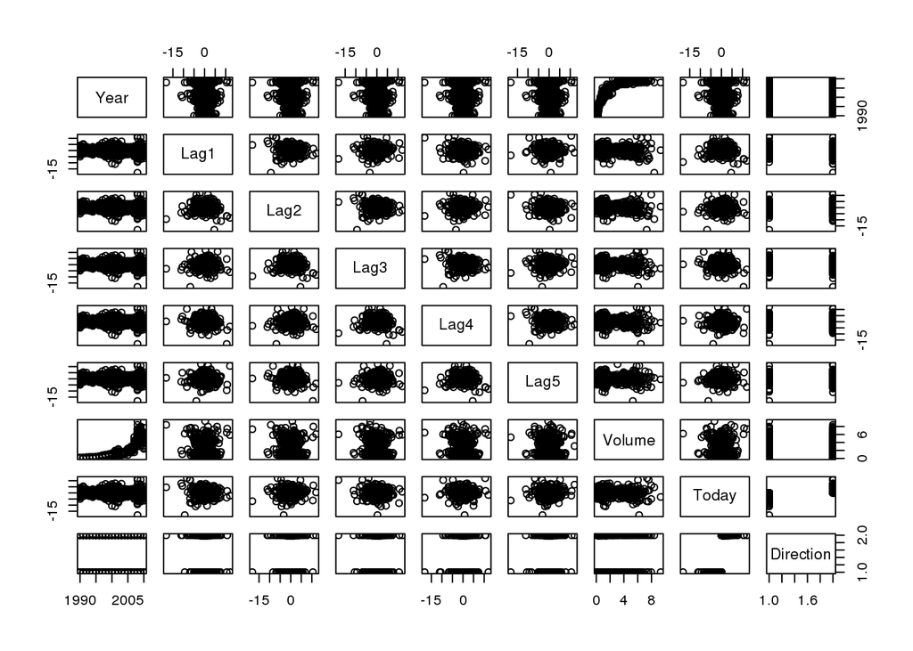

```r
pairs(Weekly)
```

```r
cor(Weekly[,-9])
```

```
##               Year         Lag1        Lag2        Lag3         Lag4
## Year    1.00000000 -0.032289274 -0.03339001 -0.03000649 -0.031127923
## Lag1   -0.03228927  1.000000000 -0.07485305  0.05863568 -0.071273876
## Lag2   -0.03339001 -0.074853051  1.00000000 -0.07572091  0.058381535
## Lag3   -0.03000649  0.058635682 -0.07572091  1.00000000 -0.075395865
## Lag4   -0.03112792 -0.071273876  0.05838153 -0.07539587  1.000000000
## Lag5   -0.03051910 -0.008183096 -0.07249948  0.06065717 -0.075675027
## Volume  0.84194162 -0.064951313 -0.08551314 -0.06928771 -0.061074617
## Today  -0.03245989 -0.075031842  0.05916672 -0.07124364 -0.007825873
##                Lag5      Volume        Today
## Year   -0.030519101  0.84194162 -0.032459894
## Lag1   -0.008183096 -0.06495131 -0.075031842
## Lag2   -0.072499482 -0.08551314  0.059166717
## Lag3    0.060657175 -0.06928771 -0.071243639
## Lag4   -0.075675027 -0.06107462 -0.007825873
## Lag5    1.000000000 -0.05851741  0.011012698
## Volume -0.058517414  1.00000000 -0.033077783
## Today   0.011012698 -0.03307778  1.000000000
```

Summary: The data set ‘Weekly’ has 1089 rows and 9 columns. The column are consisted by “Year” “Lag1” “Lag2” “Lag3” “Lag4” “Lag5” “Volume” “Today” and “Direction”. The correlations btween the lag variables and today’s returns are close to 0, which means there are little correclation between today’s return and previous day’s returns. The only substantial correlation is between ‘Year’ and ‘volume’. From the plot, it shows that ‘Volume’ is increasing over time.

2. Fit a logistic regression with `Direction` as the response and different combinations of lag variables plus `Volume` as predictors. Use the period from 1990 to 2008 as your training set and 2009-2010 as your test set. Produce a summary of results.

   Do any of the predictors appear to be statistically significant in your training set? If so, which ones?

```r
train = (Weekly$Year<2009)
Weekly.train = Weekly[train,]
Weekly.test = Weekly[!train,]
glm_train <- glm(Weekly.train$Direction ~ .-Today, data = Weekly.train,family=binomial)
summary(glm_train)
```

```
##
## Call:
## glm(formula = Weekly.train$Direction ~ . - Today, family = binomial,
##     data = Weekly.train)
##
## Deviance Residuals:
##     Min       1Q   Median       3Q      Max
## -1.7215  -1.2494   0.9824   1.0847   1.4924
##
## Coefficients:
##              Estimate Std. Error z value Pr(>|z|)
## (Intercept)  2.779438  42.446904   0.065   0.9478
## Year        -0.001227   0.021282  -0.058   0.9540
## Lag1        -0.062163   0.029466  -2.110   0.0349 *
## Lag2         0.044903   0.030066   1.493   0.1353
## Lag3        -0.015305   0.029595  -0.517   0.6050
## Lag4        -0.030967   0.029342  -1.055   0.2913
## Lag5        -0.037599   0.029353  -1.281   0.2002
## Volume      -0.085115   0.096432  -0.883   0.3774
## ---
## Signif. codes:  0 '***' 0.001 '**' 0.01 '*' 0.05 '.' 0.1 ' ' 1
##
## (Dispersion parameter for binomial family taken to be 1)
##
##     Null deviance: 1354.7  on 984  degrees of freedom
## Residual deviance: 1342.3  on 977  degrees of freedom
## AIC: 1358.3
##
## Number of Fisher Scoring iterations: 4
```

```r
glm_test <- glm(Weekly.test$Direction ~ .-Today, data = Weekly.test,family=binomial)
summary(glm_test)
```

```
##
## Call:
## glm(formula = Weekly.test$Direction ~ . - Today, family = binomial,
##     data = Weekly.test)
##
## Deviance Residuals:
##     Min       1Q   Median       3Q      Max
## -1.6376  -1.2525   0.8385   1.0223   1.4282
##
## Coefficients:
##               Estimate Std. Error z value Pr(>|z|)
## (Intercept) -617.55647  931.51561  -0.663    0.507
## Year           0.30739    0.46331   0.663    0.507
## Lag1           0.04590    0.06858   0.669    0.503
## Lag2           0.09999    0.06940   1.441    0.150
## Lag3          -0.03458    0.06783  -0.510    0.610
## Lag4          -0.03797    0.06733  -0.564    0.573
## Lag5           0.09208    0.06952   1.325    0.185
## Volume         0.03201    0.20587   0.156    0.876
##
## (Dispersion parameter for binomial family taken to be 1)
##
##     Null deviance: 141.04  on 103  degrees of freedom
## Residual deviance: 136.10  on  96  degrees of freedom
## AIC: 152.1
##
## Number of Fisher Scoring iterations: 4
```

There is only 1 predictor appears to be statistically significant in training set, which is Lag1. The probability is 0.0349 which is located between 0.01 and 0.05.

3. From your test set, compute the confusion matrix, and calculate accuracy, precision, recall and F1.

   Explain what the confusion matrix is telling you about the types of mistakes made by logistic regression, and what can you learn from additional measures of fit like accuracy, precision, recall, and F1.

```r
glm.test.probs<- predict(glm_test,type="response")
contrasts(Weekly.test$Direction)
```

```
##      Up
## Down  0
## Up    1
```

```r
glm.test.pred = rep("Down",104)
glm.test.pred[glm.test.probs> 0.5] = "Up"
table (glm.test.pred, Weekly.test$Direction)
```

```
##
## glm.test.pred Down Up
##          Down   12  9
##          Up     31 52
```

```r
accuracy_test <- (12+52)/(12+9+31+52)
precision_test <- 12/(12+9)
recall_test <- 12/(12+31)
F1_test <- 2*(precision_test*recall_test)/(precision_test+recall_test)
print(c(accuracy_test,precision_test,recall_test,F1_test))
```

```
## [1] 0.6153846 0.5714286 0.2790698 0.3750000
```

In this confusion matrix, of the 43 actual “Down”, the system predicted that 31 were “Up”. And of 61 “Up”, it predicted that 9 were “Down”. The correct predictions are 12 “Down” and 52 “Up”. From the accuracy, around 61.5% prediction is correct. Probability of a “Down” sample actually in all samples predicted to be “Down” is around 0.57, which is from precision. Probability of being predicted as a “Down” sample in a sample that is actually “Down” is around 0.27. F1 of the test set is around 0.375, which is more close to the worst value 0.

4. (Extra credit) Experiment with alternative classification methods.

   Present the results of your experiments reporting method, associated confusion matrix, and measures of fit on the test set like accuracy, precision, recall, and F1.

```r
library(MASS)
lda.test <- lda(Weekly.test$Direction ~ .-Today, data = Weekly.test)
lda.test
```

```
## Call:
## lda(Weekly.test$Direction ~ . - Today, data = Weekly.test)
##
## Prior probabilities of groups:
##      Down        Up
## 0.4134615 0.5865385
##
## Group means:
##          Year      Lag1        Lag2      Lag3      Lag4        Lag5
## Down 2009.465 0.2089767 -0.08904651 0.5855349 0.6180930 -0.08146512
## Up   2009.525 0.5306230  0.69591803 0.2309344 0.1938361  0.60139344
##        Volume
## Down 5.111618
## Up   5.034022
##
## Coefficients of linear discriminants:
##                LD1
## Year    0.70459108
## Lag1    0.10330804
## Lag2    0.22057357
## Lag3   -0.07616549
## Lag4   -0.08275989
## Lag5    0.20461316
## Volume  0.06452481
```

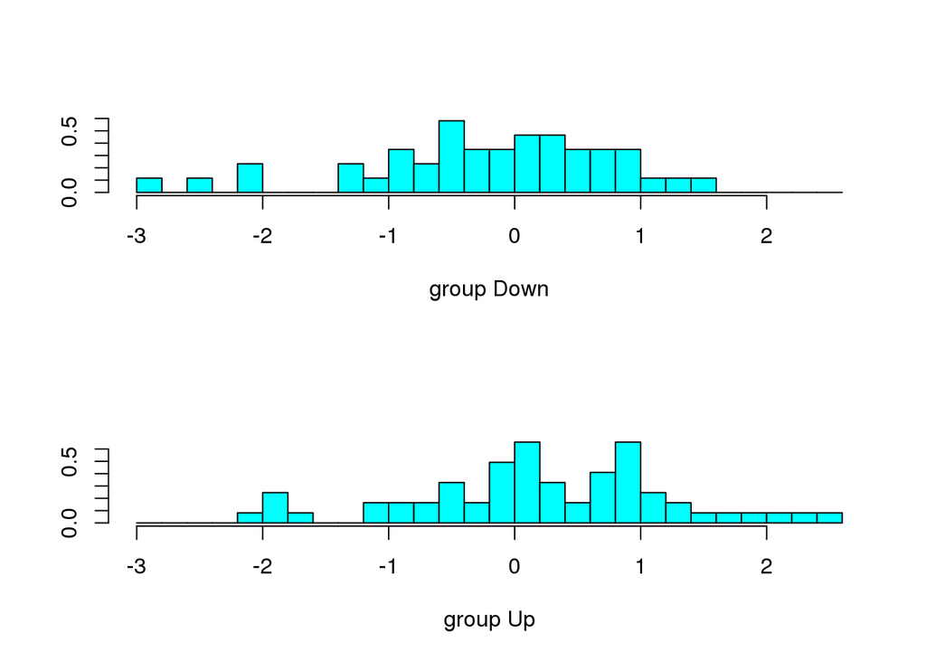

```r
plot(lda.test)
```

```r
lda.pred = predict(lda.test,Weekly.test)
names(lda.pred)
```

```
## [1] "class"     "posterior" "x"
```

```r
lda.class=lda.pred$class
table(lda.class,Weekly.test$Direction)
```

```
##
## lda.class Down Up
##      Down   10  9
##      Up     33 52
```

```r
accuracy_test1 <- (10+52)/(10+9+33+52)
precision_test1 <- 10/(10+9)
recall_test1 <- 10/(10+33)
F1_test1 <- 2*(precision_test1*recall_test1)/(precision_test1+recall_test1)
print(c(accuracy_test1,precision_test1,recall_test1,F1_test1))
```

```
## [1] 0.5961538 0.5263158 0.2325581 0.3225806
```

In this confusion matrix, of the 43 actual “Down”, the system predicted that 33 were “Up”. And of 61 “Up”, it predicted that 9 were “Down”. The correct predictions are 10 “Down” and 52 “Up”. From the accuracy, around 59.6% prediction is correct. Probability of a “Down” sample actually in all samples predicted to be “Down” is around 0.52, which is from precision. Probability of being predicted as a “Down” sample in a sample that is actually “Down” is around 0.23. F1 of the test set is around 0.3225, which is more close to the worst value 0.